# Ensembles_ANW

### Project # 3: Ensemble Techniques - Term Deposit Subscription Prediction

#### Context

The data is related with direct marketing campaigns of a Portuguese banking institution. The marketing campaigns were based on phone calls. Often, more than one contact to the same client was required, in order to access if the product (bank term deposit) would be ('yes') or not ('no') subscribed.

#### Dataset

The historical data for this project is available in file https://archive.ics.uci.edu/ml/datasets/Bank+Marketing

#### Goal

Term Deposit Subscription Prediction - Using the data collected from existing customers, a model will be developed that can help the marketing team identify potential customers who are relatively more likely to subscribe term deposit and thus increase their hit ratio.

### Input variables:

#### Alex N Waithera - Project 3 : Ensemble Models

# 1. Exploratory Data Analysis (EDA)

```python
#Import the libraries to use
import warnings
warnings.filterwarnings('ignore')
import numpy as np
import pandas as pd
import matplotlib.pyplot as plt
import copy
import seaborn as sns
%matplotlib inline
from sklearn.model_selection import train_test_split
from sklearn.tree import DecisionTreeClassifier
from sklearn.metrics import accuracy_score, f1_score, recall_score, precision_score, confusion_matrix
from sklearn.preprocessing import StandardScaler
from sklearn.preprocessing import Normalizer
from sklearn.linear_model import LogisticRegression
from sklearn.metrics import roc_auc_score
from sklearn.metrics import roc_curve
from sklearn.tree import DecisionTreeClassifier
from yellowbrick.classifier import ClassificationReport, ROCAUC
#from sklearn.feature_extraction.text import CountVectorizer  #DT does not take strings as input for the model fit step....
from IPython.display import Image
#import pydotplus as pydot
from sklearn import tree
from os import system
```

```python
#Load and review data using pandas
df = pd.read_csv("bank-full.csv")

df.head()
```

|  | age | job | marital | education | default | balance | housing | loan | contact | day | month | duration | campaign | pdays | previous | poutcome | Target |
| --- | --- | --- | --- | --- | --- | --- | --- | --- | --- | --- | --- | --- | --- | --- | --- | --- | --- |
| 0 | 58 | management | married | tertiary | no | 2143 | yes | no | unknown | 5 | may | 261 | 1 | -1 | 0 | unknown | no |
| 1 | 44 | technician | single | secondary | no | 29 | yes | no | unknown | 5 | may | 151 | 1 | -1 | 0 | unknown | no |
| 2 | 33 | entrepreneur | married | secondary | no | 2 | yes | yes | unknown | 5 | may | 76 | 1 | -1 | 0 | unknown | no |
| 3 | 47 | blue-collar | married | unknown | no | 1506 | yes | no | unknown | 5 | may | 92 | 1 | -1 | 0 | unknown | no |
| 4 | 33 | unknown | single | unknown | no | 1 | no | no | unknown | 5 | may | 198 | 1 | -1 | 0 | unknown | no |

```python
# Display statistical summary of the dataset
df.describe()
```

|  | age | balance | day | duration | campaign | pdays | previous |
| --- | --- | --- | --- | --- | --- | --- | --- |
| count | 45211.000000 | 45211.000000 | 45211.000000 | 45211.000000 | 45211.000000 | 45211.000000 | 45211.000000 |
| mean | 40.936210 | 1362.272058 | 15.806419 | 258.163080 | 2.763841 | 40.197828 | 0.580323 |
| std | 10.618762 | 3044.765829 | 8.322476 | 257.527812 | 3.098021 | 100.128746 | 2.303441 |
| min | 18.000000 | -8019.000000 | 1.000000 | 0.000000 | 1.000000 | -1.000000 | 0.000000 |
| 25% | 33.000000 | 72.000000 | 8.000000 | 103.000000 | 1.000000 | -1.000000 | 0.000000 |
| 50% | 39.000000 | 448.000000 | 16.000000 | 180.000000 | 2.000000 | -1.000000 | 0.000000 |
| 75% | 48.000000 | 1428.000000 | 21.000000 | 319.000000 | 3.000000 | -1.000000 | 0.000000 |
| max | 95.000000 | 102127.000000 | 31.000000 | 4918.000000 | 63.000000 | 871.000000 | 275.000000 |

#### Observation:

- The dataset has about 45211 entries and 17 variables.
- Of the 17 variables, 10 variables i.e. 'job', 'marital', 'education', 'contact' ,'default','housing', 'loan', 'poutcome', 'Target' & 'month' are categorical variables while the other seven(7) variables are numerical, that is: 'Age', 'balance', 'day', 'duration', 'campaign', 'pdays' and 'previous'.
- Based on the problem statement, our target variable is to predict whether the client subscribed for a term deposit or not.

```python
# Display information and shape of the dataframe:
df.info()
df.shape
```

```
<class 'pandas.core.frame.DataFrame'>
RangeIndex: 45211 entries, 0 to 45210
Data columns (total 17 columns):
age          45211 non-null int64
job          45211 non-null object
marital      45211 non-null object
education    45211 non-null object
default      45211 non-null object
balance      45211 non-null int64
housing      45211 non-null object
loan         45211 non-null object
contact      45211 non-null object
day          45211 non-null int64
month        45211 non-null object
duration     45211 non-null int64
campaign     45211 non-null int64
pdays        45211 non-null int64
previous     45211 non-null int64
poutcome     45211 non-null object
Target       45211 non-null object
dtypes: int64(7), object(10)
memory usage: 5.9+ MB
```

```
(45211, 17)
```

```python
# Check datatype
df.dtypes
```

```
age           int64
job          object
marital      object
education    object
default      object
balance       int64
housing      object
loan         object
contact      object
day           int64
month        object
duration      int64
campaign      int64
pdays         int64
previous      int64
poutcome     object
Target       object
dtype: object
```

```python
# Print non-null number of the movings ratings data
df.count()
#Check for any null values in the dataset
df.isnull().values.any()
```

```
False
```

```python
# count number of missing values in each column
# sum True's
df.isnull().sum()
```

```
age          0
job          0
marital      0
education    0
default      0
balance      0
housing      0
loan         0
contact      0
day          0
month        0
duration     0
campaign     0
pdays        0
previous     0
poutcome     0
Target       0
dtype: int64
```

```python
# Check the unique values in each column of the dataframe.
df.nunique()
```

```
age            77
job            12
marital         3
education       4
default         2
balance      7168
housing         2
loan            2
contact         3
day            31
month          12
duration     1573
campaign       48
pdays         559
previous       41
poutcome        4
Target          2
dtype: int64
```

```python
#Check datatypes
df.info()
```

```
<class 'pandas.core.frame.DataFrame'>
RangeIndex: 45211 entries, 0 to 45210
Data columns (total 17 columns):
age          45211 non-null int64
job          45211 non-null object
marital      45211 non-null object
education    45211 non-null object
default      45211 non-null object
balance      45211 non-null int64
housing      45211 non-null object
loan         45211 non-null object
contact      45211 non-null object
day          45211 non-null int64
month        45211 non-null object
duration     45211 non-null int64
campaign     45211 non-null int64
pdays        45211 non-null int64
previous     45211 non-null int64
poutcome     45211 non-null object
Target       45211 non-null object
dtypes: int64(7), object(10)
memory usage: 5.9+ MB
```

Observation:

- The dataset has 45211 rows and 17 columns.
- The 45211 entries are a combination of int64 and object non-null values.
- This dataset does not have any missing values, null values or duplicates.

## 1(a) Univariate Analysis

### - Univariate Analysis for Categorical Variables

```python
#Univariate analysis of the 'job' independent variable
print(df['job'].value_counts(normalize=True))
```

```
blue-collar      0.215257
management       0.209197
technician       0.168034
admin.           0.114375
services         0.091880
retired          0.050076
self-employed    0.034925
entrepreneur     0.032890
unemployed       0.028820
housemaid        0.027427
student          0.020747
unknown          0.006370
Name: job, dtype: float64
```

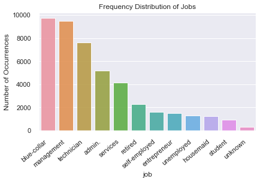

```python
job_count = df['job'].value_counts()
sns.set(style="darkgrid")
ax = sns.barplot(job_count.index, job_count.values, alpha=0.9)
ax.set_xticklabels(ax.get_xticklabels(), rotation=40, ha="right") #this rotates the ticklabels to make them more readable.
plt.tight_layout()
plt.title('Frequency Distribution of Jobs')
plt.ylabel('Number of Occurrences', fontsize=12)
plt.xlabel('job', fontsize=12)
plt.show()
```

## Observation

- The number of people in this dataset that have a blue-collar job status are about 22%,followed by management (21%),then technician (17%) and admin.(11%). The rest of the people have job segments i.e (services,retired, self-employed, entrepreneur, unemployed, housemaid, student,and unknown) make about 29% of the share.
- The 'job' variable is categorical and will be encoded to a numerical feature before running the model.

```python
#Univariate analysis of the 'marital' independent variable
print(df['marital'].value_counts(normalize=True))
```

```
married     0.601933
single      0.282896
divorced    0.115171
Name: marital, dtype: float64
```

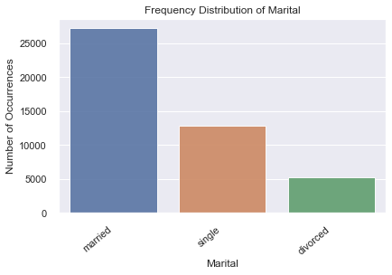

```python
marital_count = df['marital'].value_counts()
sns.set(style="darkgrid")
ax = sns.barplot(marital_count.index, marital_count.values, alpha=0.9)
ax.set_xticklabels(ax.get_xticklabels(), rotation=40, ha="right") #this rotates the ticklabels to make them more readable.
plt.tight_layout()
plt.title('Frequency Distribution of Marital')
plt.ylabel('Number of Occurrences', fontsize=12)
plt.xlabel('Marital', fontsize=12)
plt.show()
```

## Observation

- The number of people that are married in this dataset is about 60%, followed by those with a single status, 28% and then 12% with a divorced status.

```python
#Univariate analysis of the 'education' independent variable
print(df['education'].value_counts(normalize=True))
```

```
secondary    0.513194
tertiary     0.294198
primary      0.151534
unknown      0.041074
Name: education, dtype: float64
```

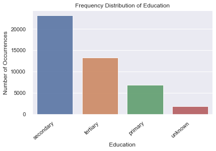

```python
education_count = df['education'].value_counts()
sns.set(style="darkgrid")
ax = sns.barplot(education_count.index, education_count.values, alpha=0.9)
ax.set_xticklabels(ax.get_xticklabels(), rotation=40, ha="right") #this rotates the ticklabels to make them more readable.
plt.tight_layout()
plt.title('Frequency Distribution of Education')
plt.ylabel('Number of Occurrences', fontsize=12)
plt.xlabel('Education', fontsize=12)
plt.show()
```

### Observation

```python
#Univariate analysis of the 'housing' independent variable
print(df['housing'].value_counts(normalize = True))
```

```
yes    0.555838
no     0.444162
Name: housing, dtype: float64
```

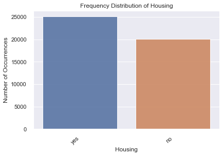

```python
housing_count = df['housing'].value_counts()
sns.set(style="darkgrid")
ax = sns.barplot(housing_count.index, housing_count.values, alpha=0.9)
ax.set_xticklabels(ax.get_xticklabels(), rotation=40, ha="right") #this rotates the ticklabels to make them more readable.
plt.tight_layout()
plt.title('Frequency Distribution of Housing')
plt.ylabel('Number of Occurrences', fontsize=12)
plt.xlabel('Housing', fontsize=12)
plt.show()
```

### Observation

- About 56% of the people in the dataset have a housing loan while about 44% do not have.

```python
#Univariate analysis of the 'poutcome' independent variable
print(df['poutcome'].value_counts(normalize = True))
```

```
unknown    0.817478
failure    0.108403
other      0.040698
success    0.033421
Name: poutcome, dtype: float64
```

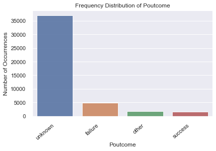

```python
poutcome_count = df['poutcome'].value_counts()
sns.set(style="darkgrid")
ax = sns.barplot(poutcome_count.index, poutcome_count.values, alpha=0.9)
ax.set_xticklabels(ax.get_xticklabels(), rotation=40, ha="right") #this rotates the ticklabels to make them more readable.
plt.tight_layout()
plt.title('Frequency Distribution of Poutcome')
plt.ylabel('Number of Occurrences', fontsize=12)
plt.xlabel('Poutcome', fontsize=12)
plt.show()
```

### Observation

- For this dataset, the status of the previous marketing campaign show only three percent (3%) success rate and about 11% failure rate. The status of the previous marketing campaign for about 82% of the people in the dataset is captured as unknown and about four percent (4%) is categorized as other.

```python
#Univariate analysis of the 'default' independent variable
print(df['default'].value_counts(normalize = True))
```

```
no     0.981973
yes    0.018027
Name: default, dtype: float64
```

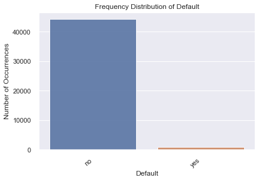

```python
default_count = df['default'].value_counts()
sns.set(style="darkgrid")
ax = sns.barplot(default_count.index, default_count.values, alpha=0.9)
ax.set_xticklabels(ax.get_xticklabels(), rotation=40, ha="right") #this rotates the ticklabels to make them more readable.
plt.tight_layout()
plt.title('Frequency Distribution of Default')
plt.ylabel('Number of Occurrences', fontsize=12)
plt.xlabel('Default', fontsize=12)
plt.show()
```

## Observation

- Only 2% of the people are categorized to have defaulted in credit while about 98% have not.

```python
#Univariate analysis of the 'loan' independent variable
print(df['loan'].value_counts(normalize = True))
```

```
no     0.839774
yes    0.160226
Name: loan, dtype: float64
```

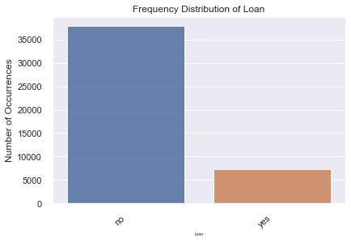

```python
loan_count = df['loan'].value_counts()
sns.set(style="darkgrid")
ax = sns.barplot(loan_count.index, loan_count.values, alpha=0.9)
ax.set_xticklabels(ax.get_xticklabels(), rotation=40, ha="right") #this rotates the ticklabels to make them more readable.
plt.tight_layout()
plt.title('Frequency Distribution of Loan')
plt.ylabel('Number of Occurrences', fontsize=12)
plt.xlabel('Loan', fontsize=5)
plt.show()
```

## Observation

- About 16% of the participants already have a loan while a majority (84%) do not have a loan.

```python
#Univariate analysis of the 'Target' dependent variable
print(df['Target'].value_counts(normalize = True))
```

```
no     0.883015
yes    0.116985
Name: Target, dtype: float64
```

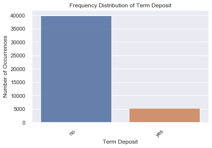

```python
Target_count = df['Target'].value_counts()
sns.set(style="darkgrid")
ax = sns.barplot(Target_count.index, Target_count.values, alpha=0.9)
ax.set_xticklabels(ax.get_xticklabels(), rotation=40, ha="right") #this rotates the ticklabels to make them more readable.
plt.tight_layout()
plt.title('Frequency Distribution of Term Deposit')
plt.ylabel('Number of Occurrences', fontsize=12)
plt.xlabel('Term Deposit', fontsize=12)
plt.show()
```

### Observation

- Only 12% of the participants subscribed to term deposit while a large percentage (88%) did not subscribe.

```python
#Univariate analysis of the 'month' independent variable
print(df['month'].value_counts(normalize = True))
```

```
may    0.304483
jul    0.152507
aug    0.138174
jun    0.118135
nov    0.087810
apr    0.064851
feb    0.058592
jan    0.031032
oct    0.016323
sep    0.012807
mar    0.010551
dec    0.004733
Name: month, dtype: float64
```

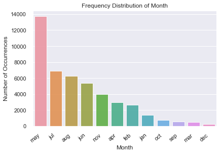

```python
month_count = df['month'].value_counts()
sns.set(style="darkgrid")
ax = sns.barplot(month_count.index, month_count.values, alpha=0.9)
ax.set_xticklabels(ax.get_xticklabels(), rotation=40, ha="right") #this rotates the ticklabels to make them more readable.
plt.tight_layout()
plt.title('Frequency Distribution of Month')
plt.ylabel('Number of Occurrences', fontsize=12)
plt.xlabel('Month', fontsize=12)
plt.show()
```

## Observation

- The month of May has the highest percentages of participants being contacted at 30% followed by July, August, June and November at 15%, 14%, 12% and nine percent (9%), respectively of participants contacted during these months. April, February, January, October, September, March and December have the least number of contacts, with a combined percentage of about 20%.

```python
#Univariate analysis of the 'contact' independent variable
print(df['contact'].value_counts(normalize = True))
```

```
cellular     0.647741
unknown      0.287983
telephone    0.064276
Name: contact, dtype: float64
```

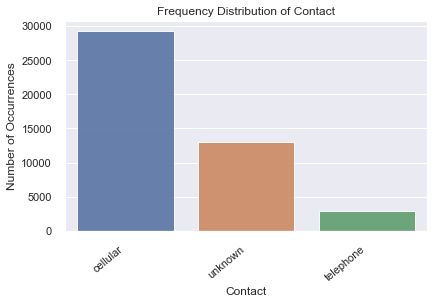

```python
contact_count = df['contact'].value_counts()
sns.set(style="darkgrid")
ax = sns.barplot(contact_count.index, contact_count.values, alpha=0.9)
ax.set_xticklabels(ax.get_xticklabels(), rotation=40, ha="right") #this rotates the ticklabels to make them more readable.
plt.tight_layout()
plt.title('Frequency Distribution of Contact')
plt.ylabel('Number of Occurrences', fontsize=12)
plt.xlabel('Contact', fontsize=12)
plt.show()
```

### Observation

- About 65% of the participants contacted was done through cellular means or mobile phones, six percent (6%) by telephone and 29% of participants were contacted using unknown means.

### Data Insights

- The above univariate analysis for categorical features show a data imbalance for the target variable with about 88% no cases and only 12% yes cases.Other features that show data imbalance are 'poutcome', 'default' and 'loan'. The rest of the categorical features are slightly uniform.
- About 10 features are categorical and therefore we will need to apply encoding, with the exception of the target variable.
- In this regard,both label and one-hot-encoding will be applied. The encoding to be applied will be based on how many classes.
- This encoding will be performed during the the data preparation stage before applying the machine learning model.

### - Univariate Analysis for Numerical Variables

```python
df.describe()
```

|  | age | balance | day | duration | campaign | pdays | previous |
| --- | --- | --- | --- | --- | --- | --- | --- |
| count | 45211.000000 | 45211.000000 | 45211.000000 | 45211.000000 | 45211.000000 | 45211.000000 | 45211.000000 |
| mean | 40.936210 | 1362.272058 | 15.806419 | 258.163080 | 2.763841 | 40.197828 | 0.580323 |
| std | 10.618762 | 3044.765829 | 8.322476 | 257.527812 | 3.098021 | 100.128746 | 2.303441 |
| min | 18.000000 | -8019.000000 | 1.000000 | 0.000000 | 1.000000 | -1.000000 | 0.000000 |
| 25% | 33.000000 | 72.000000 | 8.000000 | 103.000000 | 1.000000 | -1.000000 | 0.000000 |
| 50% | 39.000000 | 448.000000 | 16.000000 | 180.000000 | 2.000000 | -1.000000 | 0.000000 |
| 75% | 48.000000 | 1428.000000 | 21.000000 | 319.000000 | 3.000000 | -1.000000 | 0.000000 |
| max | 95.000000 | 102127.000000 | 31.000000 | 4918.000000 | 63.000000 | 871.000000 | 275.000000 |

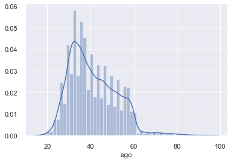

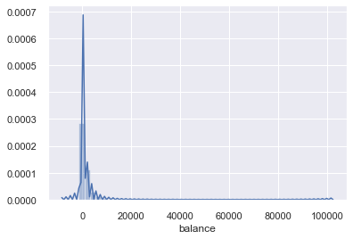

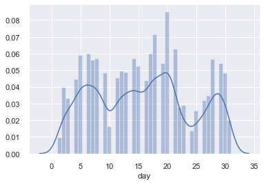

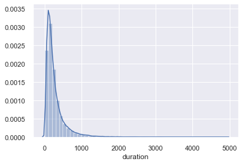

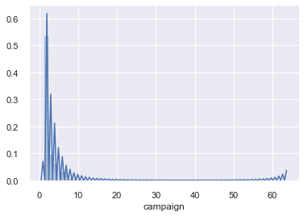

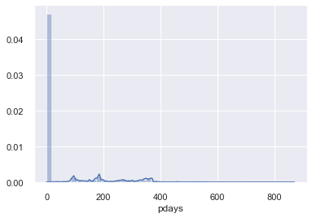

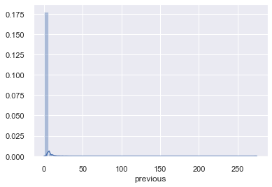

```python
# Analyse data distribution in the continous variables using vizualization:
for i in ['age','balance','day', 'duration', 'campaign', 'pdays', 'previous']:
    sns.distplot(df[i])
    plt.show()
```

### Strategies to address data pollution, outliers and missing values.

- No missing values were detected from the above analysis.
- Data imbalance between classes was detected by using vizualization and the value counts function.
- For categorical features, label encoding will be used to differentiate between categorical features that have more value counts than their counterparts as captured label encoding section.
- Outliers eventhough not a big issue when dealing with ensemble models were detected and removed using the percentile method as captured below.
- After removal of extreme outliers, the entries were reduced from the initial 45211 to 45205 entries as captured below:

```python
df.describe()
```

|  | age | balance | day | duration | campaign | pdays | previous |
| --- | --- | --- | --- | --- | --- | --- | --- |
| count | 45211.000000 | 45211.000000 | 45211.000000 | 45211.000000 | 45211.000000 | 45211.000000 | 45211.000000 |
| mean | 40.936210 | 1362.272058 | 15.806419 | 258.163080 | 2.763841 | 40.197828 | 0.580323 |
| std | 10.618762 | 3044.765829 | 8.322476 | 257.527812 | 3.098021 | 100.128746 | 2.303441 |
| min | 18.000000 | -8019.000000 | 1.000000 | 0.000000 | 1.000000 | -1.000000 | 0.000000 |
| 25% | 33.000000 | 72.000000 | 8.000000 | 103.000000 | 1.000000 | -1.000000 | 0.000000 |
| 50% | 39.000000 | 448.000000 | 16.000000 | 180.000000 | 2.000000 | -1.000000 | 0.000000 |
| 75% | 48.000000 | 1428.000000 | 21.000000 | 319.000000 | 3.000000 | -1.000000 | 0.000000 |
| max | 95.000000 | 102127.000000 | 31.000000 | 4918.000000 | 63.000000 | 871.000000 | 275.000000 |

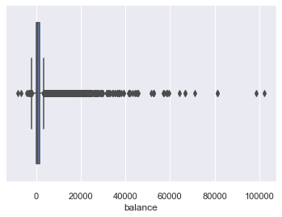

```python
#Detecting & removing outliers in the 'balance' variable
sns.boxplot(df['balance'])
```

```python
# Removal of extreme outliers using the percentile method:
# Since we are using ensemble models that are robust in dealing with outliers,only extreme outliers will be removed.
# Removal of the extreme outliers did not change the accuracy of the ensemble models as anticipated.

max_threshold = df['balance'].quantile(1)

df[df['balance']< max_threshold]

min_threshold =df['balance'].quantile(0.0)
df[df['balance']> min_threshold]
#Remove outliers
df2 = df[(df.balance<max_threshold) & (df.balance>min_threshold)]
df2.shape
```

```
(45209, 17)
```

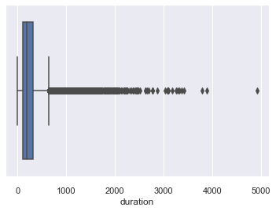

```python
#Detecting & removing outliers in the 'duration' variable
sns.boxplot(df['duration'])
```

```python
max_threshold = df['duration'].quantile(1.0)

df2[df2['duration']< max_threshold]

min_threshold =df2['duration'].quantile(0.0)

df2[df2['duration']> min_threshold]
#Remove outliers
df3 = df2[(df2.duration<max_threshold) & (df2.duration>min_threshold)]
df3.shape
```

```
(45205, 17)
```

## 1(b) Bivariate Analysis

- Bivariate analysis was used to check mainly the relationship of the Target variable with independent variables.

```python
df3.shape
```

```
(45205, 17)
```

```python
df3.columns
```

```
Index(['age', 'job', 'marital', 'education', 'default', 'balance', 'housing',
       'loan', 'contact', 'day', 'month', 'duration', 'campaign', 'pdays',
       'previous', 'poutcome', 'Target'],
      dtype='object')
```

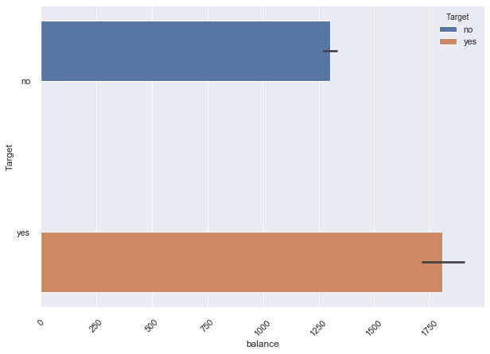

```python
#Inspect balance versus Target
plt.figure(figsize=(10,7))
sns.barplot(x = "balance", y = "Target", hue = "Target", data = df3)
plt.xticks(rotation=45)
plt.show()
```

#### Observation

- Participants that have high balances on their account did subscribe more to a term deposit compared to those with lower balances on their account.

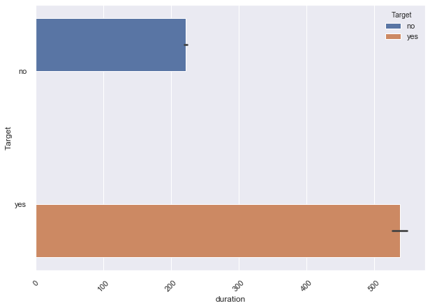

```python
#Inspect duration versus Target
plt.figure(figsize=(10,7))
sns.barplot(x = "duration", y = "Target", hue = "Target", data= df3)
plt.xticks(rotation=45)
plt.show()
```

#### Observation

- Partipants that subscribed to a term deposit spend more time (longer duration in seconds) when they were contacted in the last campaign.

#### - One-hot-encoding and Label encoding

```python
print(df3.job.value_counts())
print(df3.marital.value_counts())
print(df3.education.value_counts())
print(df3.default.value_counts())
print(df3.housing.value_counts())
print(df3.loan.value_counts())
print(df3.poutcome.value_counts())
print(df3.month.value_counts())
print(df3.contact.value_counts())
```

```
blue-collar      9731
management       9456
technician       7595
admin.           5171
services         4154
retired          2264
self-employed    1579
entrepreneur     1486
unemployed       1303
housemaid        1240
student           938
unknown           288
Name: job, dtype: int64
married     27210
single      12788
divorced     5207
Name: marital, dtype: int64
secondary    23199
tertiary     13299
primary       6850
unknown       1857
Name: education, dtype: int64
no     44391
yes      814
Name: default, dtype: int64
yes    25127
no     20078
Name: housing, dtype: int64
no     37963
yes     7242
Name: loan, dtype: int64
unknown    36953
failure     4901
other       1840
success     1511
Name: poutcome, dtype: int64
may    13764
jul     6894
aug     6246
jun     5340
nov     3969
apr     2932
feb     2649
jan     1403
oct      738
sep      579
mar      477
dec      214
Name: month, dtype: int64
cellular     29281
unknown      13019
telephone     2905
Name: contact, dtype: int64
```

- Categorical features were encoded first and different weights assigned to the different classes based on their value counts. High weights were assigned to categorical classes with high value counts and vice-versa. Unknown classes were assigned with negative one (-1) where it makes sense to do so.
- One-hot-encoding was applied to categorical variables that are less complex such as 'loan', 'default', 'housing' or fetures with atmost two classes (yes or no).

```python
# One-hot-encoding and Label encoding
# High weights were assigned to categorical classes with high value counts and vice-versa.
#Unknown classes were assigned with negative one (-1) where it makes sense to do so.
replaceStruct = {
                "job":     {"blue-collar": 11, "management": 10 ,"technician": 9 ,"admin.": 8, "services": 7, "retired": 6, "self-employed": 5, "entrepreneur": 4, "unemployed": 3, "housemaid": 2, "student": 1, "unknown": -1},
                "marital": {"married": 3, "single":2 , "divorced": 1},
                 "month": {"may": 12, "jul": 11 , "aug": 10, "jun": 9,"nov": 8, "apr": 7, "feb": 6, "jan": 5, "oct": 4, "sep": 3, "mar": 2, "dec": 1},
                 "poutcome":     {"failure": 3, "unknown": -1 ,"other": 2 ,"success": 1},
                "education":     {"secondary": 3, "tertiary": 2, "primary": 1, "unknown": -1},
                "contact":     {"cellular": 2,"telephone": 1, "unknown": -1},
                    }
oneHotCols=["loan","default","housing"]
```

```python
df3 = df3.replace(replaceStruct)
df3 = pd.get_dummies(df3, columns=oneHotCols)
df3.head(10)
```

|  | age | job | marital | education | balance | contact | day | month | duration | campaign | pdays | previous | poutcome | Target | loan_no | loan_yes | default_no | default_yes | housing_no | housing_yes |
| --- | --- | --- | --- | --- | --- | --- | --- | --- | --- | --- | --- | --- | --- | --- | --- | --- | --- | --- | --- | --- |
| 0 | 58 | 10 | 3 | 2 | 2143 | -1 | 5 | 12 | 261 | 1 | -1 | 0 | -1 | no | 1 | 0 | 1 | 0 | 0 | 1 |
| 1 | 44 | 9 | 2 | 3 | 29 | -1 | 5 | 12 | 151 | 1 | -1 | 0 | -1 | no | 1 | 0 | 1 | 0 | 0 | 1 |
| 2 | 33 | 4 | 3 | 3 | 2 | -1 | 5 | 12 | 76 | 1 | -1 | 0 | -1 | no | 0 | 1 | 1 | 0 | 0 | 1 |
| 3 | 47 | 11 | 3 | -1 | 1506 | -1 | 5 | 12 | 92 | 1 | -1 | 0 | -1 | no | 1 | 0 | 1 | 0 | 0 | 1 |
| 4 | 33 | -1 | 2 | -1 | 1 | -1 | 5 | 12 | 198 | 1 | -1 | 0 | -1 | no | 1 | 0 | 1 | 0 | 1 | 0 |
| 5 | 35 | 10 | 3 | 2 | 231 | -1 | 5 | 12 | 139 | 1 | -1 | 0 | -1 | no | 1 | 0 | 1 | 0 | 0 | 1 |
| 6 | 28 | 10 | 2 | 2 | 447 | -1 | 5 | 12 | 217 | 1 | -1 | 0 | -1 | no | 0 | 1 | 1 | 0 | 0 | 1 |
| 7 | 42 | 4 | 1 | 2 | 2 | -1 | 5 | 12 | 380 | 1 | -1 | 0 | -1 | no | 1 | 0 | 0 | 1 | 0 | 1 |
| 8 | 58 | 6 | 3 | 1 | 121 | -1 | 5 | 12 | 50 | 1 | -1 | 0 | -1 | no | 1 | 0 | 1 | 0 | 0 | 1 |
| 9 | 43 | 9 | 2 | 3 | 593 | -1 | 5 | 12 | 55 | 1 | -1 | 0 | -1 | no | 1 | 0 | 1 | 0 | 0 | 1 |

```python
df3.info()
```

```
<class 'pandas.core.frame.DataFrame'>
Int64Index: 45205 entries, 0 to 45210
Data columns (total 20 columns):
age            45205 non-null int64
job            45205 non-null int64
marital        45205 non-null int64
education      45205 non-null int64
balance        45205 non-null int64
contact        45205 non-null int64
day            45205 non-null int64
month          45205 non-null int64
duration       45205 non-null int64
campaign       45205 non-null int64
pdays          45205 non-null int64
previous       45205 non-null int64
poutcome       45205 non-null int64
Target         45205 non-null object
loan_no        45205 non-null uint8
loan_yes       45205 non-null uint8
default_no     45205 non-null uint8
default_yes    45205 non-null uint8
housing_no     45205 non-null uint8
housing_yes    45205 non-null uint8
dtypes: int64(13), object(1), uint8(6)
memory usage: 5.4+ MB
```

## 1(c) Multivariate analysis

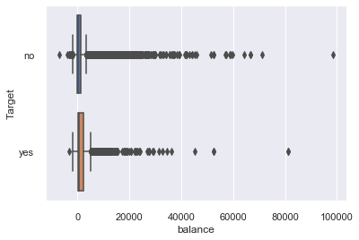

```python
sns.boxplot(df3['balance'], df3['Target']);
```

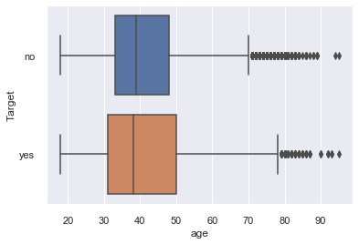

```python
sns.boxplot(df3['age'], df3['Target']);
```

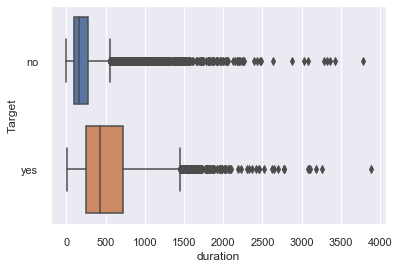

```python
sns.boxplot(df3['duration'], df3['Target']);
```

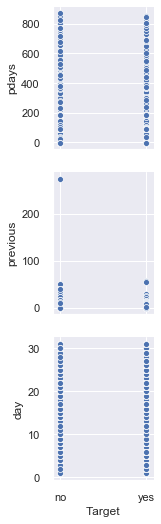

```python
sns.pairplot(data=df3,
                  x_vars=['Target'],
                  y_vars=['pdays', 'previous', 'day'])
```

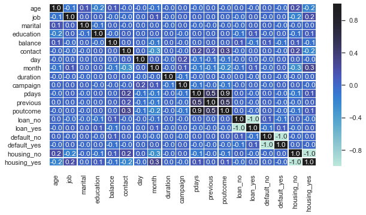

```python
plt.figure(figsize=(10,5))
sns.heatmap(df3.corr(), annot=True, linewidths=.5, fmt= '.1f', center = 1 )  # heatmap
plt.show()
```

### Observation

- Bivariate analysis between predictor variables and the target feature show no strong relationship or any correlation.
- The numerical variables: 'pdays' and 'poutcome' have a strong correlation at 0.9
- The numerical variables: 'previous' and 'pdays' have a weak correlation at 0.5
- However, dropping of any of these redudant features seem not to affect the accuracy of the different models that are applied below.

# 2. Data Preparation for Analysis

### 2(a) Get the data model ready

```python
# splitting data into training and test set for independent attributes
## Define X and Y variables
X = df3.drop(['Target','poutcome', 'previous'], axis=1)
Y = df3[['Target']]
```

```python
# Standardize data (0 mean, 1 stdev)
scaler = StandardScaler().fit(X)
X = scaler.transform(X)
```

```python
# Normalize data (length of 1)
scaler = Normalizer().fit(X)
X = scaler.transform(X)
```

```python
##Split into training and test set in the ratio of 70:30
from sklearn.model_selection import train_test_split

features = [col for col in df3.columns if col != 'Target']

X_train, X_test, y_train, y_test = train_test_split(df3[features], df3['Target'], test_size=.3, random_state=42)
X_train.shape, X_test.shape
```

```
((31643, 19), (13562, 19))
```

# 3. Creation of the Ensemble Models

### 3(a) Decision Tree Algorithm/model

```python
# Application of the decision tree classifier function using the 'entropy' method of finding the split columns.
# Applying 'gini' criterion produced the same accuracy for the ensemble models as the 'entropy' criterion.

model_entropy = DecisionTreeClassifier(criterion='entropy')
```

```python
model_entropy.fit(X_train, y_train)
```

```
DecisionTreeClassifier(ccp_alpha=0.0, class_weight=None, criterion='entropy',
                       max_depth=None, max_features=None, max_leaf_nodes=None,
                       min_impurity_decrease=0.0, min_impurity_split=None,
                       min_samples_leaf=1, min_samples_split=2,
                       min_weight_fraction_leaf=0.0, presort='deprecated',
                       random_state=None, splitter='best')
```

```python
print("Train: %.2f" % model_entropy.score(X_train, y_train))  # performance on train data
print("Test: %.2f" % model_entropy.score(X_test, y_test))  # performance on test data
```

```
Train: 1.00
Test: 0.88
```

```python
clf_pruned = DecisionTreeClassifier(criterion = "entropy", max_depth=4)
clf_pruned.fit(X_train, y_train)
```

```
DecisionTreeClassifier(ccp_alpha=0.0, class_weight=None, criterion='entropy',
                       max_depth=4, max_features=None, max_leaf_nodes=None,
                       min_impurity_decrease=0.0, min_impurity_split=None,
                       min_samples_leaf=1, min_samples_split=2,
                       min_weight_fraction_leaf=0.0, presort='deprecated',
                       random_state=None, splitter='best')
```

```python
print("Train: %.2f" % clf_pruned.score(X_train, y_train))  # performance on train data
print("Test: %.2f" % clf_pruned.score(X_test, y_test))  # performance on test data
```

```
Train: 0.90
Test: 0.89
```

```python
from sklearn.tree import export_graphviz
from sklearn.externals.six import StringIO
from IPython.display import Image
import pydotplus
import graphviz
```

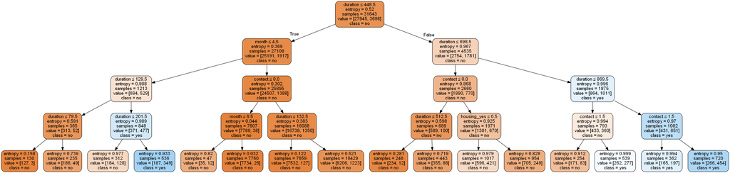

```python
dot_data = StringIO()
export_graphviz(clf_pruned, out_file=dot_data,
                filled=True, rounded=True,
                special_characters=True,feature_names = features,class_names=['no','yes'])
graph = pydotplus.graph_from_dot_data(dot_data.getvalue())
graph.write_png('Target_pruned.png')
Image(graph.create_png())
```

```python
preds_train = clf_pruned.predict(X_train)
preds_test = clf_pruned.predict(X_test)

acc_DT = accuracy_score(y_test, preds_test)
```

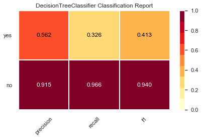

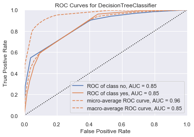

```python
# Visualize model performance with yellowbrick library
viz = ClassificationReport(DecisionTreeClassifier(criterion = "entropy", max_depth=4))
viz.fit(X_train, y_train)
viz.score(X_test, y_test)
viz.show()

roc = ROCAUC(DecisionTreeClassifier(criterion = "entropy", max_depth=4))
roc.fit(X_train, y_train)
roc.score(X_test, y_test)
roc.show()
```

### 3(b) Logistic Regression Algorithm/Model

```python
model = LogisticRegression(solver='liblinear')
model.fit(X_train, y_train)
predicted = model.predict(X_test)
matrix = confusion_matrix(y_test, predicted)
print(matrix)
```

```
[[11708   263]
 [ 1239   352]]
```

```python
from sklearn.linear_model import LogisticRegression
from sklearn.metrics import classification_report
model = LogisticRegression(solver='liblinear')
model.fit(X_train, y_train)
predicted = model.predict(X_test)
report = classification_report(y_test, predicted)
print(report)
```

```
              precision    recall  f1-score   support

          no       0.90      0.98      0.94     11971
         yes       0.57      0.22      0.32      1591

    accuracy                           0.89     13562
   macro avg       0.74      0.60      0.63     13562
weighted avg       0.87      0.89      0.87     13562
```

### 3(c) Building the ensemble models (Bagging and Boosting) and noting the model performance by using different matrices.

### - Application of the Random forest model

```python
#Store the accuracy results for each model in a dataframe for final comparison
resultsDf = pd.DataFrame({'Method':['Decision Tree'], 'accuracy': acc_DT})
resultsDf = resultsDf[['Method', 'accuracy']]
resultsDf
```

|  | Method | accuracy |
| --- | --- | --- |
| 0 | Decision Tree | 0.891166 |

```python
from sklearn.ensemble import RandomForestClassifier
rfcl = RandomForestClassifier(n_estimators = 50)
rfcl = rfcl.fit(X_train, y_train)
```

```python
pred_RF = rfcl.predict(X_test)
acc_RF = accuracy_score(y_test, pred_RF)
```

```python
tempResultsDf = pd.DataFrame({'Method':['Random Forest'], 'accuracy': [acc_RF]})
resultsDf = pd.concat([resultsDf, tempResultsDf])
resultsDf = resultsDf[['Method', 'accuracy']]
resultsDf
```

|  | Method | accuracy |
| --- | --- | --- |
| 0 | Decision Tree | 0.891166 |
| 0 | Random Forest | 0.906651 |

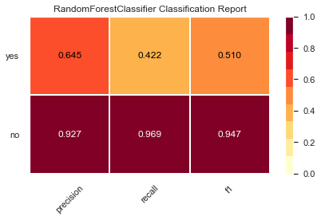

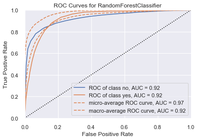

```python
# Visualize model performance with yellowbrick library
viz = ClassificationReport(RandomForestClassifier(n_estimators = 50))
viz.fit(X_train, y_train)
viz.score(X_test, y_test)
viz.show()

roc = ROCAUC(RandomForestClassifier(n_estimators = 50))
roc.fit(X_train, y_train)
roc.score(X_test, y_test)
roc.show()
```

```python
from sklearn.linear_model import LogisticRegression
model = LogisticRegression(solver='liblinear')
LR = LogisticRegression(solver='liblinear')
LR = LR.fit(X_train, y_train)
```

```python
pred_LR = LR.predict(X_test)
acc_LR = accuracy_score(y_test, pred_LR)
```

```python
tempResultsDf = pd.DataFrame({'Method':['Logistic Regression'], 'accuracy': [acc_LR]})
resultsDf = pd.concat([resultsDf, tempResultsDf])
resultsDf = resultsDf[['Method', 'accuracy']]
resultsDf
```

|  | Method | accuracy |
| --- | --- | --- |
| 0 | Decision Tree | 0.891166 |
| 0 | Random Forest | 0.906651 |
| 0 | Logistic Regression | 0.889249 |

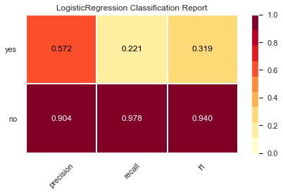

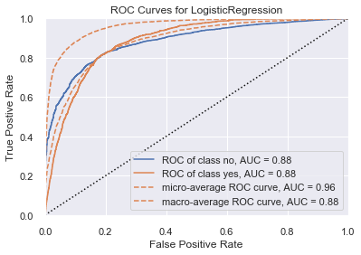

```python
# Visualize model performance with yellowbrick library
viz = ClassificationReport(LogisticRegression(solver='liblinear'))
viz.fit(X_train, y_train)
viz.score(X_test, y_test)
viz.show()

roc = ROCAUC(LogisticRegression(solver='liblinear'))
roc.fit(X_train, y_train)
roc.score(X_test, y_test)
roc.show()
```

### - Application of Adaboost Ensemble Algorithm.

```python
from sklearn.ensemble import AdaBoostClassifier
abcl = AdaBoostClassifier(n_estimators = 100, learning_rate=0.1, random_state=22)
abcl = abcl.fit(X_train, y_train)
```

```python
pred_AB =abcl.predict(X_test)
acc_AB = accuracy_score(y_test, pred_AB)
```

```python
tempResultsDf = pd.DataFrame({'Method':['Adaboost'], 'accuracy': [acc_AB]})
resultsDf = pd.concat([resultsDf, tempResultsDf])
resultsDf = resultsDf[['Method', 'accuracy']]
resultsDf
```

|  | Method | accuracy |
| --- | --- | --- |
| 0 | Decision Tree | 0.891166 |
| 0 | Random Forest | 0.906651 |
| 0 | Logistic Regression | 0.889249 |
| 0 | Adaboost | 0.888512 |

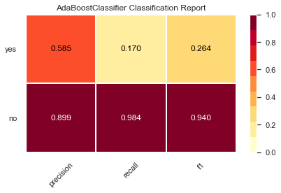

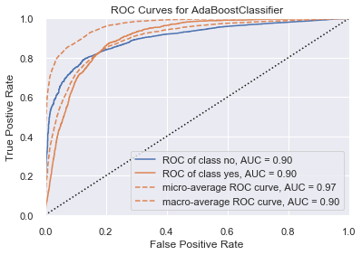

```python
# Visualize model performance with yellowbrick library
viz = ClassificationReport(AdaBoostClassifier(n_estimators= 100, learning_rate=0.1, random_state=22))
viz.fit(X_train, y_train)
viz.score(X_test, y_test)
viz.show()

roc = ROCAUC(AdaBoostClassifier(n_estimators= 100, learning_rate=0.1, random_state=22))
roc.fit(X_train, y_train)
roc.score(X_test, y_test)
roc.show()
```

### - Application of the Bagging Classifier Algorithm

```python
from sklearn.ensemble import BaggingClassifier

bgcl = BaggingClassifier(n_estimators=50, max_samples= .7, bootstrap=True, oob_score=True, random_state=22)
bgcl = bgcl.fit(X_train, y_train)
```

```python
pred_BG = bgcl.predict(X_test)
acc_BG = accuracy_score(y_test, pred_BG)
```

```python
tempResultsDf = pd.DataFrame({'Method':['Bagging'], 'accuracy': [acc_BG]})
resultsDf = pd.concat([resultsDf, tempResultsDf])
resultsDf = resultsDf[['Method', 'accuracy']]
resultsDf
```

|  | Method | accuracy |
| --- | --- | --- |
| 0 | Decision Tree | 0.891166 |
| 0 | Random Forest | 0.906651 |
| 0 | Logistic Regression | 0.889249 |
| 0 | Adaboost | 0.888512 |
| 0 | Bagging | 0.905029 |

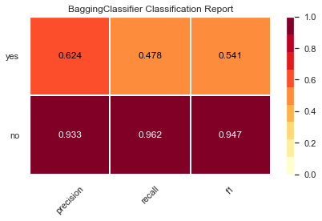

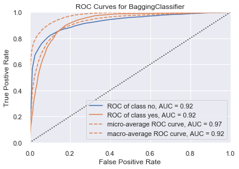

```python
# Visualize model performance with yellowbrick library
viz = ClassificationReport(BaggingClassifier(n_estimators=50, max_samples= .7, bootstrap=True, oob_score=True, random_state=22))
viz.fit(X_train, y_train)
viz.score(X_test, y_test)
viz.show()

roc = ROCAUC(BaggingClassifier(n_estimators=50, max_samples= .7, bootstrap=True, oob_score=True, random_state=22))
roc.fit(X_train, y_train)
roc.score(X_test, y_test)
roc.show()
```